# Factor Variables

# Creating factor variables

# 인자 변수 만들기

인자 변수는 숫자 또는 문자열 변수가 될 수 있는 범주형 변수이다 범주형 변수를 인자 변수로 전환하는데에 많은 장점들이 있다. 가장 중요한 이점은 정확하게 수행되어져야 할 통계적 모델링에 사용된다는 것이다. 인자 변수는 많은 다양한 그래픽 형태에서 매우 유용하다. 게다가, 인자 변수로 문자열 변수를 저장하는 것은 메모리 사용에 효율적이다. 인자 변수를 만들기 위해, ** factor ** 함수를 사용한다. 필수 인자는 숫자 또는 문자열로 이루어진 벡터값이다. 선택 인자는 인자 변수의 범주를 결정하는 ** levels ** 인자를 포함한다. 그리고 기본값은 벡터 데이터의 모든 별개의 값들을 정렬한 리스트이다. 또 다른 선택 옵션은 ** labels **가 있다. 이는** levels ** 인자 안에 범주들의 라벨을이 되는 값들의 벡터이다. ** exclude ** 인자 또한 선택 인자인데, 이는 어떤 levels가 인자 변수를 사용하는 어느 결과물 안에서나 NA로 분류화 되어질 수 있는지 결정한d다.

먼저 **schtyp** 라 불리는 숫자형 데이터 벡터를 생성한다. 이는 무작위의 숫자 생성기를 포함하여 복사(재생)할 수 있는 결과를 만들기 위해 124와 같은 씨앗(seed)를 셋팅한다.

```r
set.seed(124)
schtyp <- sample(0:1, 20, replace = TRUE)
schtyp
```

```
##  [1] 0 0 1 0 0 0 1 0 1 0 1 1 1 1 0 0 1 1 1 0
```

```r
is.factor(schtyp)
```

```
## [1] FALSE
```

```r
is.numeric(schtyp)
```

```
## [1] TRUE
```

이제 schtyp를 기반으로하여 schtyp.f라 불리는 인자 변수를 만들어보자. 첫번째 라벳은 private이며 schtyp=0과 일치할 것이고, 두번째 라벨은 public이며 schtyp=1과 일치할 것이다. 왜냐하면 라벨의 순서는 데이터의 숫자 순서를 따르기 때문이다.

```r
schtyp.f <- factor(schtyp, labels = c("private", "public"))
schtyp.f
```

```
##  [1] private private public  private private private public  private
##  [9] public  private public  public  public  public  private private
## [17] public  public  public  private
## Levels: private public
```

```r
is.factor(schtyp.f)
```

```
## [1] TRUE
```

다음으로 ses(socio-economic status)라 불리는 문자열 변수를 만든다.

```r
ses <- c("low", "middle", "low", "low", "low", "low", "middle", "low", "middle", "middle", "middle", "middle", "middle", "high", "high", "low", "middle", "middle", "low", "high")

is.factor(ses)
```

```
## [1] FALSE
```

ses 변수를 기반으로 ses.f.bad.order라는 인자 변수를 만든다.

```r
ses.f.bad.order <- factor(ses)
is.factor(ses.f.bad.order)
```

```
## [1] TRUE
```

```r
levels(ses.f.bad.order)
```

```
## [1] "high"   "low"    "middle"
```

```r
ses.f <- factor(ses, levels = c("low", "middle", "high"))
is.factor(ses.f)
```

```
## [1] TRUE
```

```r
levels(ses.f)
```

```
## [1] "low"    "middle" "high"
```

## 2. Creating Ordered factor variables

‘ordered’ 기능을 사용하여 정렬된 인자 변수를 만들 수 있다. 이 기능은 ‘factor’ 기능과 같은 인자를 가진다. 위의 예에서 만든 **ses** 변수를 기반으로 **Ses.order** 이름으로 정렬된 인자 변수를 만들어보자.

```r
ses.order <- ordered(ses, levels = c("low", "middle", "high"))
ses
```

```
##  [1] "low"    "middle" "low"    "low"    "low"    "low"    "middle"
##  [8] "low"    "middle" "middle" "middle" "middle" "middle" "high"
## [15] "high"   "low"    "middle" "middle" "low"    "high"
```

```r
ses.order
```

```
##  [1] low    middle low    low    low    low    middle low    middle middle
## [11] middle middle middle high   high   low    middle middle low    high
## Levels: low < middle < high
```

```r
is.factor(ses.order)
```

```
## [1] TRUE
```

## 3. Adding and dropping levels in factor variables

## 3. 인자 변수의 수준 추가 및 삭제

아래에서 우리는 “very.high” 라는 새로운 수준의 요소를 우리가 만든 **ses.f** 변수에 추가할 것이다. 사각 괄호안의 숫자 ([21])은 우리가 바꾸길 원하는 라벨을 가진 요소의 숫자를 가리킨다.

```r
ses.f[21] <- "very.high"
ses.f
```

```
##  [1] low    middle low    low    low    low    middle low    middle middle
## [11] middle middle middle high   high   low    middle middle low    high
## [21] <NA>
## Levels: low middle high
```

```r
ses.f <- factor(ses.f, levels = c(levels(ses.f), "very.high"))
ses.f[21] <- "very.high"
ses.f
```

```
##  [1] low       middle    low       low       low       low       middle
##  [8] low       middle    middle    middle    middle    middle    high
## [15] high      low       middle    middle    low       high      very.high
## Levels: low middle high very.high
```

```r
levels(ses.f)
```

```
## [1] "low"       "middle"    "high"      "very.high"
```

인자변수의 수준 삭제는 조금 더 쉽다. 가장 간단한 방법은 먼저 삭제할 수준 안의 모든 요소들을 삭제하고, 인자 변수에 변수를 재선언하는 것이다. 만약 그 수준에 요소가 없다면 그 수준은 자동적으로 삭제 되지 않는다. 왜냐하면, 우리는 특정한 수준으로부터의 요소들을 포함하고 있지 않은 샘플을 가질 수 있었다(?). **ses.f** 변수에 “very.high” 수준을 삭제해보자

```r
ses.f.new <- ses.f[ses.f != "very.high"]
ses.f.new
```

```
##  [1] low    middle low    low    low    low    middle low    middle middle
## [11] middle middle middle high   high   low    middle middle low    high
## Levels: low middle high very.high
```

```r
ses.f.new <-factor(ses.f.new)
ses.f.new
```

```
##  [1] low    middle low    low    low    low    middle low    middle middle
## [11] middle middle middle high   high   low    middle middle low    high
## Levels: low middle high
```

```r
levels(ses.f.new)
```

```
## [1] "low"    "middle" "high"
```

## 4. Examples of the usefulness of factor variables

## 4. 인자 변수의 유용성의 예제

인자변수의 유용성을 보여주기 위해, 먼저 우리가 이전 예제에서 사용했던 모든 변수들을 가지는 데이터 프레임을 만들 것이다. 그리 추가적인 **read** 로 명명한 읽기 점수를 포함하는 연속 변수를 더할 것이다. 또, **ses.f**가 “Very.high” 요소가 없는 **ses.f.new** 변수와 같게끔 재정의할 것이다.

```r
ses.f <- ses.f.new
read <- c(34, 39, 63, 44, 47, 47, 57, 39, 48, 47, 34, 37, 47, 47, 39, 47, 47, 50, 28, 60)

# combining all the variables in a data frame
combo <- data.frame(schtyp, schtyp.f, ses, ses.f, read)
```

인자 변수를 사용할 때 테이블들 해석하기 더 쉽다. 왜냐하면 인자변수는 유용한 라벨들을 테이블에 추가하고 더 이해하기 쉬운 순서로 인자들을 배열하기 때문이다.

```r
table(ses, schtyp)
```

```
##         schtyp
## ses      0 1
##   high   2 1
##   low    6 2
##   middle 2 7
```

```r
table(ses.f, schtyp.f)
```

```
##         schtyp.f
## ses.f    private public
##   low          6      2
##   middle       2      7
##   high         2      1
```

그래픽은 인자 변수의 사용으로부터 혜택을 받는 다른 영역이다. 테이블안에 따라 인자 변수는 유용한 라벨이 잘 추가 됨에 따라 더 나은 순서의 그래프를 가리킨다.

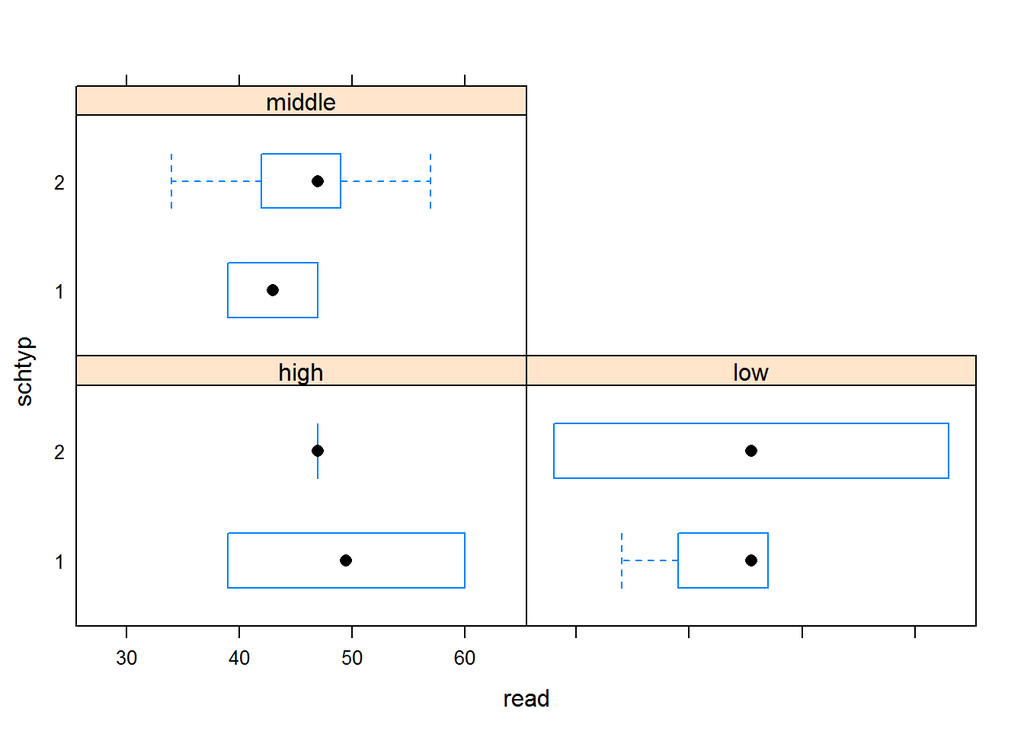

```r
library(lattice)
bwplot(schtyp ~ read | ses, data = combo, layout = c(2,2))
```

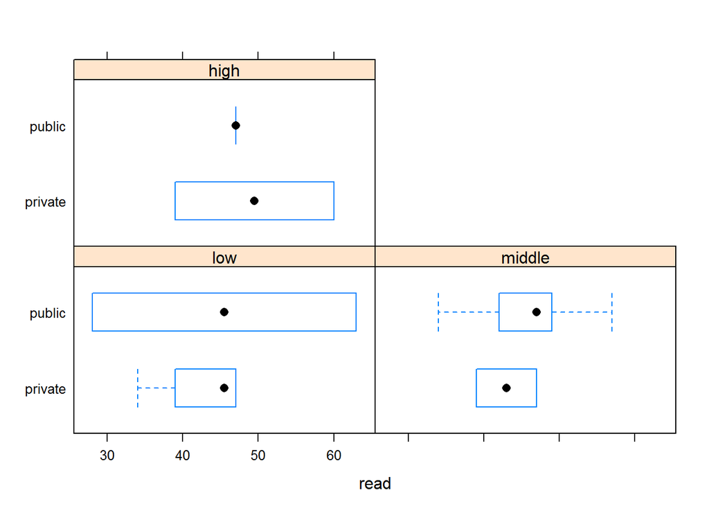

```r
bwplot(schtyp.f ~ read | ses.f, data = combo, layout = c(2,2))
```